# Assignment 1

Bhanuja Arekatla

Question 1 Loading a dataset

```r
data(iris)
summary(iris)
```

```
  Sepal.Length    Sepal.Width     Petal.Length    Petal.Width          Species
 Min.   :4.300   Min.   :2.000   Min.   :1.000   Min.   :0.100   setosa    :50
 1st Qu.:5.100   1st Qu.:2.800   1st Qu.:1.600   1st Qu.:0.300   versicolor:50
 Median :5.800   Median :3.000   Median :4.350   Median :1.300   virginica :50
 Mean   :5.843   Mean   :3.057   Mean   :3.758   Mean   :1.199
 3rd Qu.:6.400   3rd Qu.:3.300   3rd Qu.:5.100   3rd Qu.:1.800
 Max.   :7.900   Max.   :4.400   Max.   :6.900   Max.   :2.500
```

```r
head(iris)
```

|  | Sepal.Length | Sepal.Width | Petal.Length | Petal.Width | Species |
| --- | --- | --- | --- | --- | --- |
| 1 | 5.1 | 3.5 | 1.4 | 0.2 | setosa |
| 2 | 4.9 | 3.0 | 1.4 | 0.2 | setosa |
| 3 | 4.7 | 3.2 | 1.3 | 0.2 | setosa |
| 4 | 4.6 | 3.1 | 1.5 | 0.2 | setosa |
| 5 | 5.0 | 3.6 | 1.4 | 0.2 | setosa |
| 6 | 5.4 | 3.9 | 1.7 | 0.4 | setosa |

1.2-Boxplot for 4 features

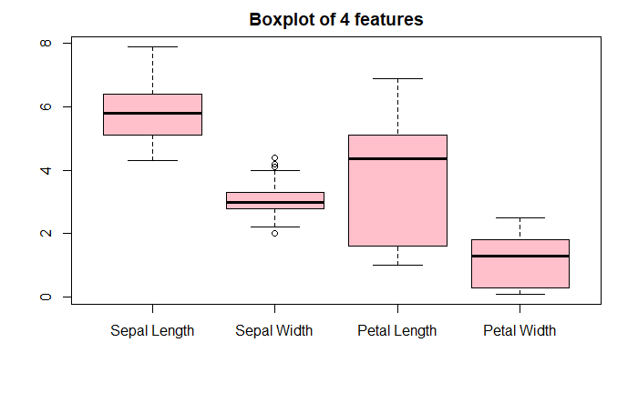

```r
  boxplot(iris$Sepal.Length,iris$Sepal.Width,iris$Petal.Length,iris$Petal.Width,main="Boxplot of 4 features",names=c("Sepal Length","Sepal Width","Petal Length","Petal Width"),col="pink")
```

1.3-Largest Empirical IQR

```r
sl=iris$Sepal.Length
sw=iris$Sepal.Width
pl=iris$Petal.Length
pw=iris$Petal.Width
```

```r
paste("IQR for Sepal Length:",IQR(sl))
```

```
[1] "IQR for Sepal Length: 1.3"
```

```r
paste("IQR for Sepal Width:",IQR(sw))
```

```
[1] "IQR for Sepal Width: 0.5"
```

```r
paste("IQR for Petal Length:",IQR(pl))
```

```
[1] "IQR for Petal Length: 3.5"
```

```r
paste("IQR for Petal Width:",IQR(pw))
```

```
[1] "IQR for Petal Width: 1.5"
```

```r
boxplot(iris$Petal.Length,main="Highest IQR is 3.5 for PetalLength",col="red",xlab="Petal.Length")
```

[output not shown]

So, We can conclude that Petal length has the largest IQR which is 3.5 from the 4 features.

1.4-Standard deviation for the 4 features

```r
paste("Standard deviation for Sepal Length:",sd(sl))
```

```
[1] "Standard deviation for Sepal Length: 0.828066127977863"
```

```r
paste("Standard deviation for Sepal Width:",sd(sw))
```

```
[1] "Standard deviation for Sepal Width: 0.435866284936698"
```

```r
paste("Standard deviation for Petal Length:",sd(pl))
```

```
[1] "Standard deviation for Petal Length: 1.76529823325947"
```

```r
paste("Standard deviation for Petal Width:",sd(pw))
```

```
[1] "Standard deviation for Petal Width: 0.762237668960347"
```

We can observe that the ratio of IQR is similar to ratio of Standard deviation and Petal length has the largest IQR.

1.5-Colored Boxplot for Sepal Length per flower species

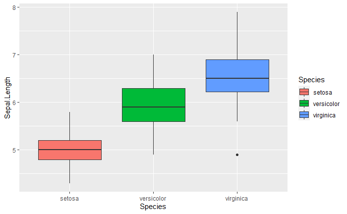

```r
library(ggplot2)
ggplot(iris,aes(y=Sepal.Length,x=Species))+geom_boxplot(aes(fill=Species))
```

Colored Boxplot for Sepal Width per flower species

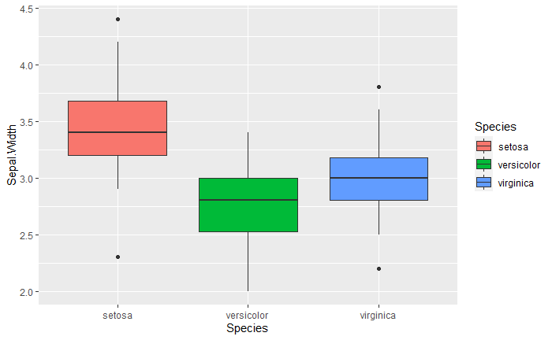

```r
ggplot(iris,aes(y=Sepal.Width,x=Species))+geom_boxplot(aes(fill=Species))
```

Colored Boxplot for Petal Length per flower species

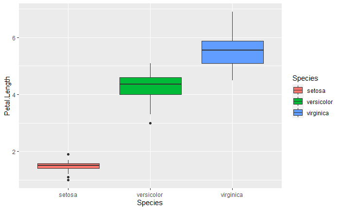

```r
ggplot(iris,aes(y=Petal.Length,x=Species))+geom_boxplot(aes(fill=Species))
```

Colored Boxplot for Petal Width per flower species

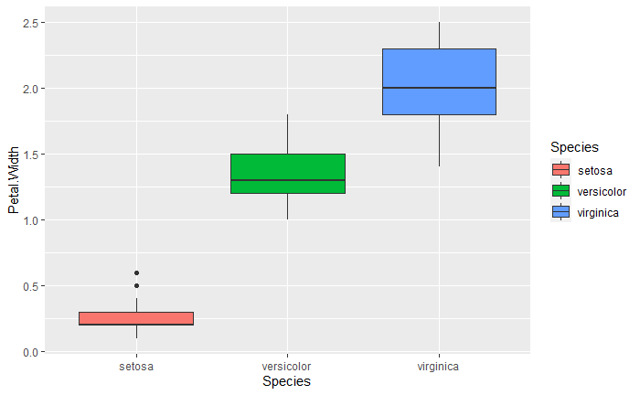

```r
ggplot(iris,aes(y=Petal.Width,x=Species))+geom_boxplot(aes(fill=Species))
```

Setosa flower has different petal length/width as compared to other species.

Question 2

2.1-Load a trees sample dataset and 5 number summary

```r
data(trees)
summary(trees)
```

```
     Girth           Height       Volume
 Min.   : 8.30   Min.   :63   Min.   :10.20
 1st Qu.:11.05   1st Qu.:72   1st Qu.:19.40
 Median :12.90   Median :76   Median :24.20
 Mean   :13.25   Mean   :76   Mean   :30.17
 3rd Qu.:15.25   3rd Qu.:80   3rd Qu.:37.30
 Max.   :20.60   Max.   :87   Max.   :77.00
```

```r
head(trees)
```

|  | Girth | Height | Volume |
| --- | --- | --- | --- |
| 1 | 8.3 | 70 | 10.3 |
| 2 | 8.6 | 65 | 10.3 |
| 3 | 8.8 | 63 | 10.2 |
| 4 | 10.5 | 72 | 16.4 |
| 5 | 10.7 | 81 | 18.8 |
| 6 | 10.8 | 83 | 19.7 |

2.2-Histogram of each vaiable

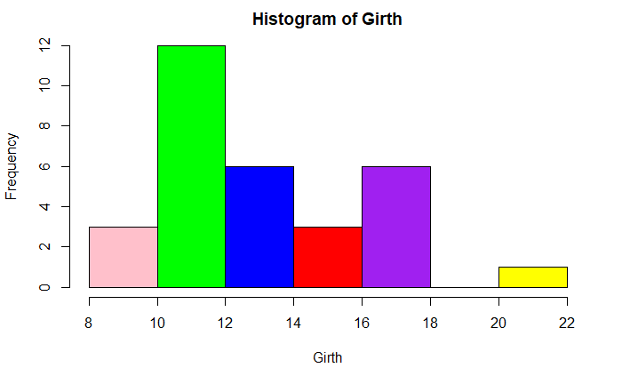

```r
hist(trees$Girth,xlab="Girth",main="Histogram of Girth",col=c("pink","green","blue","red","purple","violet","yellow"))
```

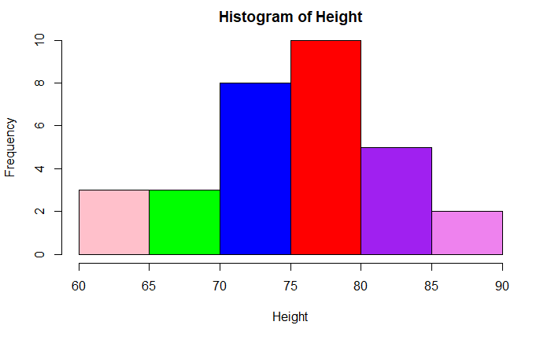

```r
hist(trees$Height,xlab="Height",main="Histogram of Height",col=c("pink","green","blue","red","purple","violet","yellow"))
```

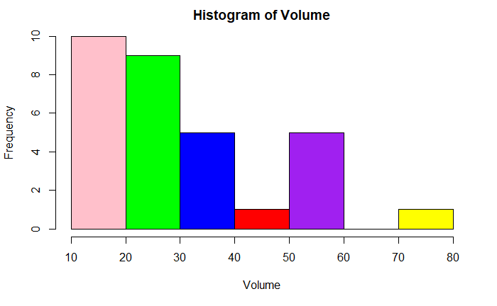

```r
hist(trees$Volume,xlab="Volume",main="Histogram of Volume",col=c("pink","green","blue","red","purple","violet","yellow"))
```

Above are the histograms for each variable.For normal distribution,the curve is symmetric at the center. So,variable Height appears to be normally distrbuted based on visual inspection.

```r
paste("Skewness of Girth is:",skewness(trees$Girth))
```

```
[1] "Skewness of Girth is: 0.526316303781635"
```

```r
paste("Skewness of Height is:",skewness(trees$Height))
```

```
[1] "Skewness of Height is: -0.374869013993998"
```

```r
paste("Skewness of Volume is:",skewness(trees$Volume))
```

```
[1] "Skewness of Volume is: 1.06435747015449"
```

We can observe that after using the function skewness(),height has negative skewness, Girth and Volume has positive skewness.

Question 3 3.1-Load the auto-mpg sample dataset from the UCI Machine Learning Repository (auto-mpg.data) into R using a dataframe (Hint: You will need to use read.csv with url, and set the appropriate values for header,as.is, and sep)

```r
data<-read.csv("https://archive.ics.uci.edu/ml/machine-learning-databases/auto-mpg/auto-mpg.data",header = FALSE, sep = "",as.is=4&9,col.names= c("mpg","cylinders","displacement","horsepower","weight","acceleration", "model year", "origin", "car name"))
print(head(data))
```

|  | mpg | cylinders | displacement | horsepower | weight | acceleration | model.year | origin | car.name |
| --- | --- | --- | --- | --- | --- | --- | --- | --- | --- |
| 1 | 18 | 8 | 307 | 130.0 | 3504 | 12.0 | 70 | 1 | chevrolet chevelle malibu |
| 2 | 15 | 8 | 350 | 165.0 | 3693 | 11.5 | 70 | 1 | buick skylark 320 |
| 3 | 18 | 8 | 318 | 150.0 | 3436 | 11.0 | 70 | 1 | plymouth satellite |
| 4 | 16 | 8 | 304 | 150.0 | 3433 | 12.0 | 70 | 1 | amc rebel sst |
| 5 | 17 | 8 | 302 | 140.0 | 3449 | 10.5 | 70 | 1 | ford torino |
| 6 | 15 | 8 | 429 | 198.0 | 4341 | 10.0 | 70 | 1 | ford galaxie 500 |

```r
summary(data)
```

```
      mpg          cylinders      displacement    horsepower            weight      acceleration
 Min.   : 9.00   Min.   :3.000   Min.   : 68.0   Length:398         Min.   :1613   Min.   : 8.00
 1st Qu.:17.50   1st Qu.:4.000   1st Qu.:104.2   Class :character   1st Qu.:2224   1st Qu.:13.82
 Median :23.00   Median :4.000   Median :148.5   Mode  :character   Median :2804   Median :15.50
 Mean   :23.51   Mean   :5.455   Mean   :193.4                      Mean   :2970   Mean   :15.57
 3rd Qu.:29.00   3rd Qu.:8.000   3rd Qu.:262.0                      3rd Qu.:3608   3rd Qu.:17.18
 Max.   :46.60   Max.   :8.000   Max.   :455.0                      Max.   :5140   Max.   :24.80
   model.year        origin        car.name
 Min.   :70.00   Min.   :1.000   Length:398
 1st Qu.:73.00   1st Qu.:1.000   Class :character
 Median :76.00   Median :1.000   Mode  :character
 Mean   :76.01   Mean   :1.573
 3rd Qu.:79.00   3rd Qu.:2.000
 Max.   :82.00   Max.   :3.000
```

```r
data$horsepower<-as.numeric(data$horsepower)
```

```
NAs introduced by coercion
```

3.2-The horsepower feature has a few missing values with a ? - and will be treated as a string. Use the as.numeric casting function to obtain the column as a numeric vector, and replace all NA values with the median.

```r
numeric_data<-data$horsepower
Median_data<-data$horsepower

no_of_missing=is.na(numeric_data)
print(table(no_of_missing))
```

```
no_of_missing
FALSE  TRUE
  392     6
```

```r
Median_data[(is.na(numeric_data))]<-median(numeric_data,na.rm = TRUE)

print(Median_data)
```

[output not shown]

3.3-How does this affect the value obtained for the mean vs the original mean when the records were ignored?

```r
median(data$horsepower,na.rm = TRUE)
```

```
[1] 93.5
```

Original Mean

```r
mean(data$horsepower,na.rm=TRUE)
```

```
[1] 104.4694
```

Mean when NA is filled with median

```r
mean(Median_data)
```

```
[1] 104.304
```